# Cluster comparison Admixture: HMP data

Kushal K Dey

November 6, 2015

```r
library(metagenomeSeq)
library(maptpx)
library(tsne)
library(qtlcharts)
library(philentropy)
library(gplots)
library(dplyr)
```

## Objective

In this script, we compare the clusters obtained from the HMP data (across all body supersites) on using admixture. The idea is to see which clusters are close to eahc other, which is equivalent to saying which body supersites are close to each other. That can give an idea about the proportion of OTUs shared across different sites.

## Data preparation

We first prepare the HMP data for applying admixture to it

```r
setwd('/Users/kushal/Documents/metagenomics/project/hands_HMP/')
load('../../data/HMPvs35_nt100_MRexperiment.rdata')
data <- t(MRcounts(hmp));
metadata <- pData(hmp);
otu_data <- featureData(hmp)
```

## Admixture by body supersite

We apply admixture on the full data grouped by the body supersite

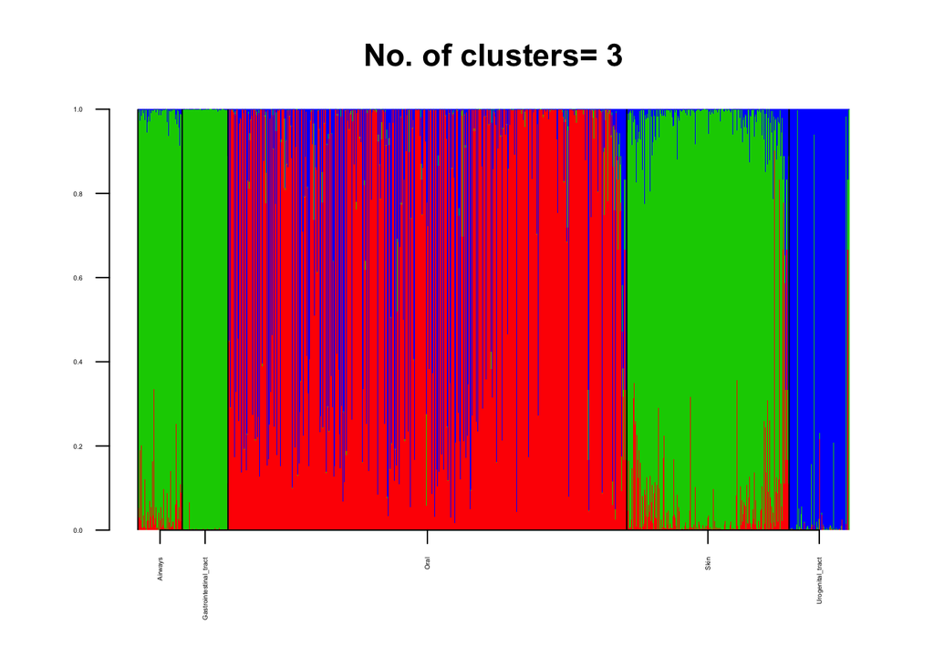

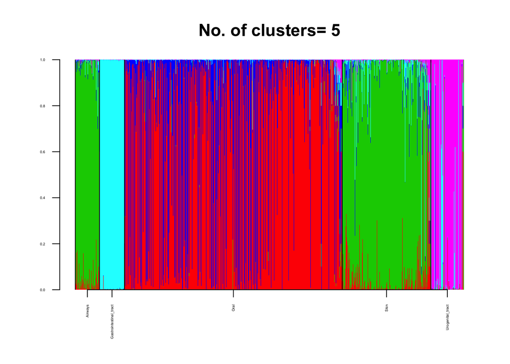

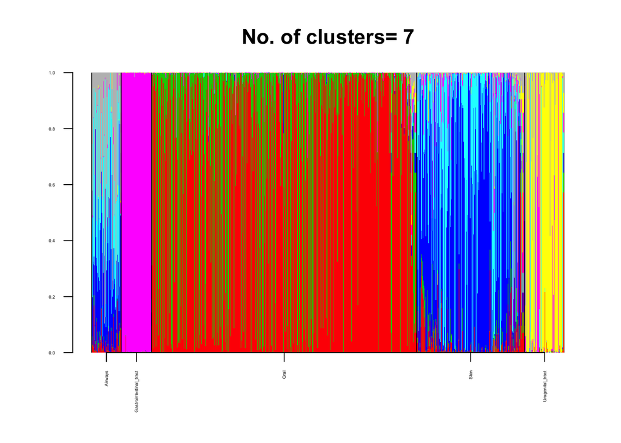

```
## [[1]]
## [1]  194.5  590.0 2539.5 5000.0 5977.0
##
## [[2]]
## [1]  194.5  590.0 2539.5 5000.0 5977.0
##
## [[3]]
## [1]  194.5  590.0 2539.5 5000.0 5977.0
```

```r
full_data <- data;
metadata <- pData(hmp);
type_bodysite <- metadata$HMPbodysupersite;
structure_body_metagenome <- function(counts_data,type_info,K)
{
#  Topic_Clus <- topics(counts_data,K,tol=0.01);
#  write.table(Topic_Clus$omega,paste0('internal_data/body_data/topics_omega_',K,'.txt'));
#  write.table(Topic_Clus$theta,paste0('internal_data/body_data/topics_theta_',K,'.txt'));
  docweights <- as.matrix(read.table(paste0('../internal_data/body_data/topics_omega_',K,'.txt')));

  type_ordered <- type_info[order(type_info)];
  docweights_ordered <- docweights[order(type_info),];
  barplot(t(docweights_ordered),col=2:(K+1),axisnames=F,space=0,border=NA,main=paste("No. of clusters=",K),las=1,ylim=c(0,1),cex.axis=0.3,cex.main=1.4);
  labels = match(unique(type_ordered), type_ordered);
  abline(v=labels-1)

  labels_low=labels-1;
  labels_up=c(labels_low[2:length(labels_low)],dim(docweights_ordered)[1]);
  mid_point <- labels_low +0.5*(labels_up-labels_low);
  axis(1,at=mid_point, unique(type_ordered),las=2,cex.axis=0.3);
}

lapply(c(3,5,7), function(n) structure_body_metagenome(full_data,type_bodysite,n));
```

## Admixture by body subsite

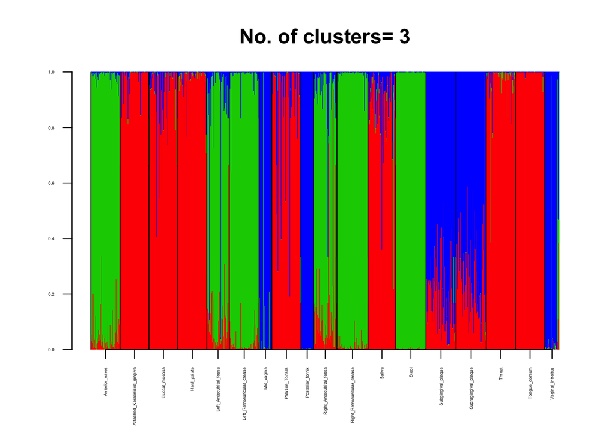

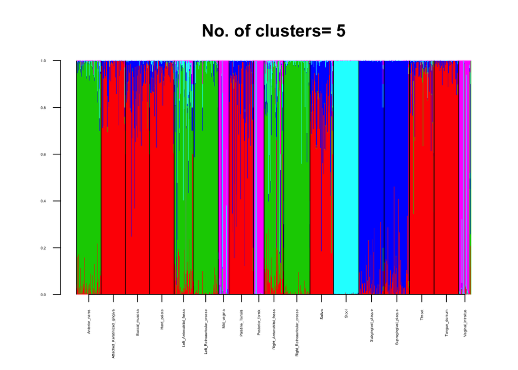

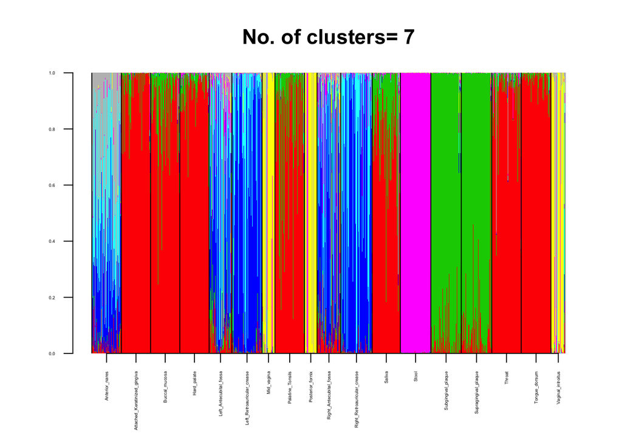

```
## [[1]]
##  [1]  194.5  581.5  966.5 1352.0 1695.0 2044.0 2327.5 2606.5 2884.0 3123.0
## [11] 3486.0 3878.5 4265.0 4666.0 5067.0 5462.0 5851.5 6144.5
##
## [[2]]
##  [1]  194.5  581.5  966.5 1352.0 1695.0 2044.0 2327.5 2606.5 2884.0 3123.0
## [11] 3486.0 3878.5 4265.0 4666.0 5067.0 5462.0 5851.5 6144.5
##
## [[3]]
##  [1]  194.5  581.5  966.5 1352.0 1695.0 2044.0 2327.5 2606.5 2884.0 3123.0
## [11] 3486.0 3878.5 4265.0 4666.0 5067.0 5462.0 5851.5 6144.5
```

```r
full_data <- data;
metadata <- pData(hmp);
type_bodysite <- metadata$HMPbodysubsite;
structure_body_metagenome <- function(counts_data,type_info,K)
{
#  Topic_Clus <- topics(counts_data,K,tol=0.01);
#  write.table(Topic_Clus$omega,paste0('internal_data/body_data/topics_omega_',K,'.txt'));
#  write.table(Topic_Clus$theta,paste0('internal_data/body_data/topics_theta_',K,'.txt'));
  docweights <- as.matrix(read.table(paste0('../internal_data/body_data/topics_omega_',K,'.txt')));

  type_ordered <- type_info[order(type_info)];
  docweights_ordered <- docweights[order(type_info),];
  barplot(t(docweights_ordered),col=2:(K+1),axisnames=F,space=0,border=NA,main=paste("No. of clusters=",K),las=1,ylim=c(0,1),cex.axis=0.3,cex.main=1.4);
  labels = match(unique(type_ordered), type_ordered);
  abline(v=labels-1)

  labels_low=labels-1;
  labels_up=c(labels_low[2:length(labels_low)],dim(docweights_ordered)[1]);
  mid_point <- labels_low +0.5*(labels_up-labels_low);
  axis(1,at=mid_point, unique(type_ordered),las=2,cex.axis=0.3);
}

lapply(c(3,5,7), function(n) structure_body_metagenome(full_data,type_bodysite,n));
```

## Cluster comparison

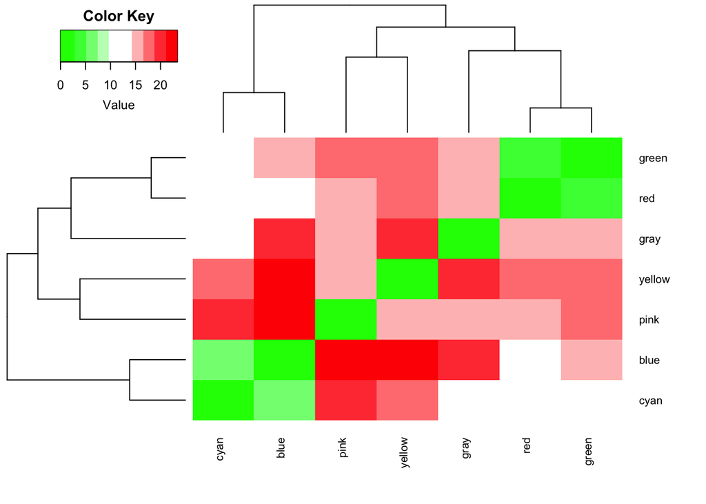

```r
K <- 7
theta_topics <- t(as.matrix(read.table(paste0('../internal_data/body_data/topics_theta_',K,'.txt'))));

## KL divergence of the different clusters

out <- distance(theta_topics, method="kullback-leibler")

#barplot(1:K,col=2:(K+1))

rownames(out) <-  c("red", "green", "blue", "cyan", "pink", "yellow", "gray");
colnames(out) <- rownames(out)

heatmap.2(out, col=c(rgb(seq(0,1,length=5),1,seq(0,1,length=5)),
                                rgb(1,seq(1,0,length=5),seq(1,0,length=5))
                                 ),
          key=T, keysize=1.5,
          density.info="none", trace="none", cexCol=0.8, cexRow=0.8)
```

## Supersite and Subsite comparison

We now do the same comaprison at the tissue level instead of the cluster level.

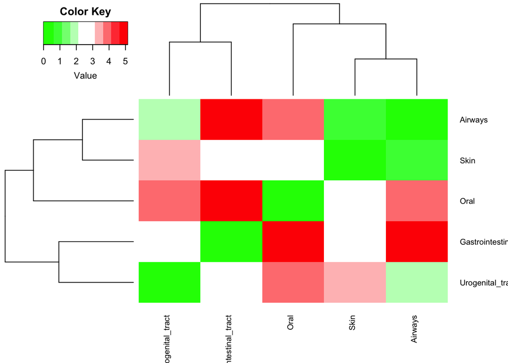

```r
K <- 7
omega_topics <- as.matrix(read.table(paste0('../internal_data/body_data/topics_omega_',K,'.txt')));

tissue_expr <- omega_topics %*% theta_topics;
names(metadata$HMPbodysupersite) <- "supersite"
tissue_expr.frame <- cbind.data.frame(metadata$HMPbodysupersite, as.matrix(tissue_expr));
colnames(tissue_expr.frame)[1] <- "supersite"
site_expr.tbl <- tissue_expr.frame %>% group_by(supersite) %>% summarise_each(funs(mean))
site_expr.frame <- data.frame(site_expr.tbl, row.names=1);

out <- distance(site_expr.frame, method="kullback-leibler")
rownames(out) <- as.vector(site_expr.tbl$supersite);
colnames(out) <- rownames(out)

heatmap.2(out, col=c(rgb(seq(0,1,length=5),1,seq(0,1,length=5)),
                                rgb(1,seq(1,0,length=5),seq(1,0,length=5))
                                 ),
          key=T, keysize=1.5,
          density.info="none", trace="none",cexCol=0.8, cexRow=0.8)
```

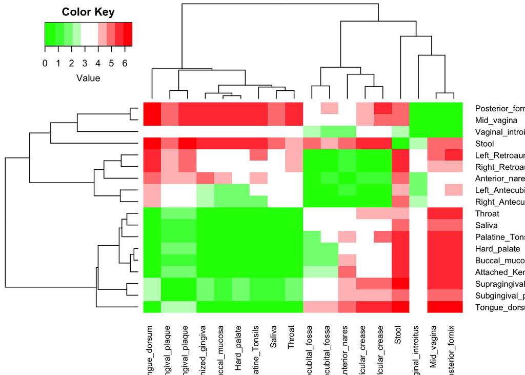

```r
tissue_expr.frame <- cbind.data.frame(metadata$HMPbodysubsite, as.matrix(tissue_expr));
colnames(tissue_expr.frame)[1] <- "subsite"
site_expr.tbl <- tissue_expr.frame %>% group_by(subsite) %>% summarise_each(funs(mean))
site_expr.frame <- data.frame(site_expr.tbl, row.names=1);

out <- distance(site_expr.frame, method="kullback-leibler")
rownames(out) <- as.vector(site_expr.tbl$subsite);
colnames(out) <- rownames(out)

heatmap.2(out, col=c(rgb(seq(0,1,length=5),1,seq(0,1,length=5)),
                                rgb(1,seq(1,0,length=5),seq(1,0,length=5))
                                 ),
          key=T, keysize=1.5,
          density.info="none", trace="none",cexCol=0.8, cexRow=0.8)
```